# Metrics to measure correlation of metaprograms

Ally Hawkins

2026-03-02

This notebook looks at the distributions of three different correlation-based metrics and attempts to define some lenient cutoffs for what’s considered a good or bad result.

Note that some of this setup code and box plot code comes from the original exploratory notebook in `03-metaprogram-comparison.Rmd`. I am repeating it here to have everything related to correlation metrics in the same place.

```r
library(ggplot2)
library(patchwork)

# Set default ggplot theme
theme_set(
  theme_bw()
)
```

## Functions

```r
# a little helper function to look at histogram and density plots for a single metric
plot_distribution <- function(df, column){

  hist <- ggplot(df, aes(x = {{ column }} )) +
    geom_histogram(fill = "grey90", color = "black")

  density <- ggplot(df, aes(x = {{ column }} )) +
    geom_density(fill = "darkblue", alpha = 0.5)

  hist / density
}
```

## Set Up

```r
# metaprograms results directory
results_dir <- here::here("ews-nf-out", "metaprograms")

# params we are looking at in this particular notebook
# use these to construct the file paths
n_metaprograms <- seq(5, 30, 1)

# directories with metaprogram results
# one directory per n_metaprogram
metaprogram_output_dirs <- file.path(
  results_dir,
  glue::glue("metaprograms-{n_metaprograms}_cnmf-5-10-15_filtered")
) |>
  # set names here so we can use them to read in the score files
  purrr::set_names(sprintf("k_%02d", n_metaprograms))


# path to files with each of the metrics
metrics_files <- file.path(metaprogram_output_dirs, "metaprograms-metrics.rds") |>
  # file.path doesn't keep the names so set them again
  purrr::set_names(sprintf("k_%02d", n_metaprograms))
```

```r
# get the metrics files
mp_metrics_list <- metrics_files |>
  purrr::map(readr::read_rds)

# create dataframe with one row per metaprogram/n_metaprogram (k) combination
# each column is a metric for that metaprograms
mp_metrics_df <- mp_metrics_list |>
  purrr::map(\(metrics_list) metrics_list$mp_metrics_df) |>
  dplyr::bind_rows(.id = "n_metaprograms")
```

```r
# path to files with the scores for each of the outputs
# each sample with each k/n_metaprograms has it's own file
# so go through each of the directories and find the score files to join together
# note that trying to read in all the files and then join at once caused R to crash
scores_df <- metaprogram_output_dirs |>
  purrr::map(\(dir){

    files <- list.files(
      path = dir,
      pattern = "_metaprogram_scores.tsv",
      recursive = TRUE,
      full.names = TRUE
    )

    # read in dataframe with metaprogra(e.g., MP01), barcodes, mp_score, and unique_id
    # one row per cell per mp
    files |>
      purrr::map(\(f) {
        readr::read_tsv(
          f,
          col_types =
            list(metaprogram = "c", barcodes = "c", mp_score = "n", unique_id = "c")
        )
      })|>
      dplyr::bind_rows()

  }) |>
  dplyr::bind_rows(.id = "n_metaprograms")
```

## Max correlation - genes

First we’ll look at the correlation of metaprograms at the gene level. This is calculated by computing the pairwise correlation of all gene weights across all metaprograms.

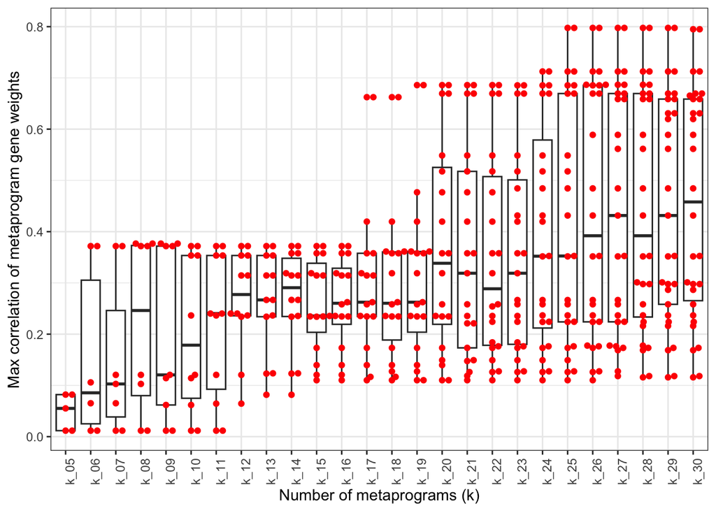

```r
ggplot(mp_metrics_df, aes(x = n_metaprograms, y = max_correlation)) +
  geom_boxplot(outlier.shape = NA) +
  ggbeeswarm::geom_beeswarm(color = "red") +
  labs(
    x = "Number of metaprograms (k)",
    y = "Max correlation of metaprogram gene weights"
  ) +
  theme(
    axis.text.x = element_text(angle = 90)
  )
```

Let’s look at the distribution of all points together regardless of the value of k to see if we can identify any obvious inflection points.

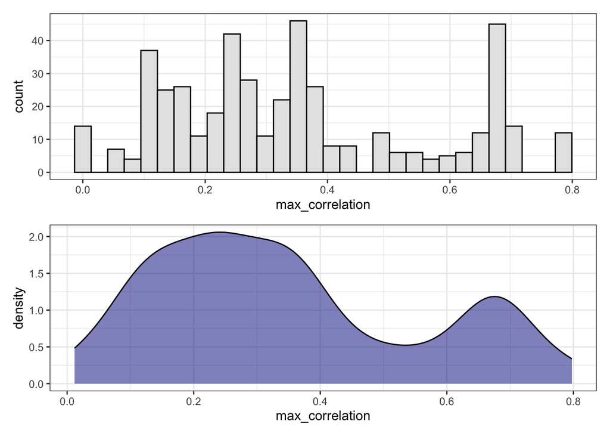

```r
plot_distribution(mp_metrics_df, max_correlation)
```

It looks like we have a bimodal distribution with an inflection point around 0.5. When we looked at the smaller range of k (5-15), all the correlations were < 0.4 and it was hard to define a cutoff but as we increase the range of k, we start to see metaprograms with much higher correlations all the way up to 0.8.

I would feel comfortable saying that “good” metaprograms are those with a max correlation < 0.5.

One way to do apply that threshold is to count the proportion of metaprograms with max correlation < 0.5 for each value of k. Let’s do that and then plot the proportion as we increase k to see at what value of k do we introduce metaprograms with high correlation. Perhaps once we see metaprograms with correlation > 0.5, we’ve gone too high and should not consider that value of k.

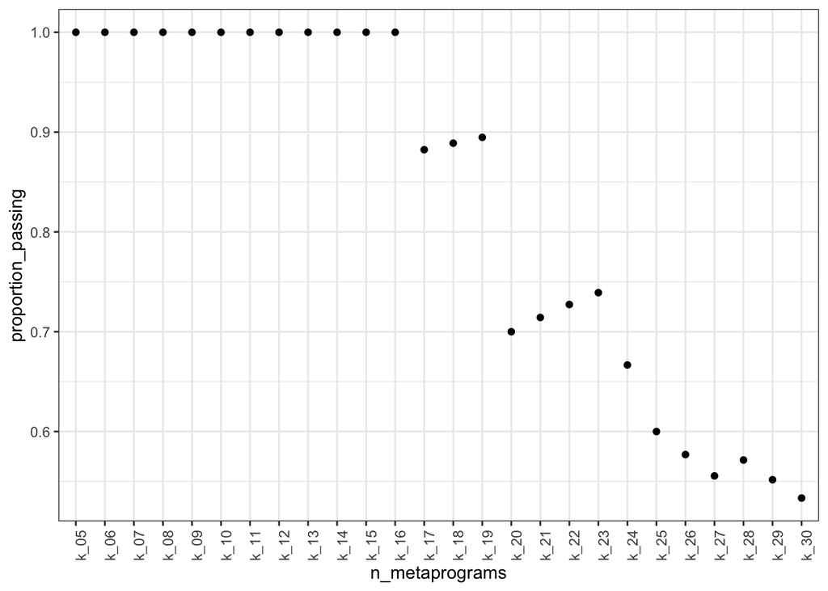

```r
correlation_elbow_df <- mp_metrics_df |>
  dplyr::mutate(
    passing_correlation = max_correlation < 0.5
  ) |>
  dplyr::group_by(n_metaprograms) |>
  dplyr::summarize(
    proportion_passing = sum(passing_correlation)/length(unique(metaprogram))
  )

ggplot(correlation_elbow_df, aes(x = n_metaprograms, proportion_passing)) +
  geom_point() +
  theme(
    axis.text.x = element_text(angle = 90)
  )
```

Alternatively, if we just get the mean of the max correlation and look for the value of k that has the minimum value?

```r
mp_metrics_df |>
  dplyr::group_by(n_metaprograms) |>
  dplyr::summarize(
    mean_correlation = mean(max_correlation)
  ) |>
  dplyr::arrange(mean_correlation)
```

| n_metaprograms | mean_correlation |
| --- | --- |
| k_05 | 0.04854628 |
| k_07 | 0.15080883 |
| k_06 | 0.15635851 |
| k_10 | 0.20070374 |
| k_09 | 0.20188825 |
| k_11 | 0.21598535 |
| k_08 | 0.21797703 |
| k_15 | 0.25928426 |
| k_16 | 0.26099086 |
| k_13 | 0.26246084 |

[output cut: 16 more lines]

Interestingly k=5 is at the top, followed by k=7, which was one of the “top” scoring metaprogram when looking at some of the sample diversity metrics. I do think this is somewhat dependent on the value of k so I think measuring the proportion of programs that meet our criteria would be a better option. For that scenario, everything for k=5 to k=15 would be equally as “good”, which I think is the right conclusion for this specific metric.

## Max correlation - cells

Next we’ll look at the correlation of scores for the top 200 genes across all cells. To do this we first get a cell by metaprogram matrix where the values correspond to the scores for that metaprogram in that cell. Then we calculate the pairwise correlation.

```r
# split by value of k
split_scores_list <- split(scores_df, scores_df$n_metaprograms)

# separately calculate the correlation of metaprograms for each value of k
# then get the max for each metaprogram and combine back into a single df for plotting
score_correlation_df <- split_scores_list |>
  purrr::map(\(df){
    mtx <- df |>
      tidyr::pivot_wider(
        names_from = "metaprogram",
        values_from = "mp_score"
      ) |>
      dplyr::mutate(cell_id = glue::glue("{unique_id}_{barcodes}")) |>
      dplyr::select(-c(n_metaprograms, unique_id, barcodes)) |>
      tibble::column_to_rownames("cell_id") |>
      as.matrix()

    # correlation of scores for each cell
    cor_mtx <- cor(mtx, method = "pearson", use = "pairwise.complete.obs")

    # get the non-self max
    diag(cor_mtx) <- 0
    max_cor_df <- data.frame(
      metaprogram = rownames(cor_mtx),
      max_correlation_cells = MatrixGenerics::rowMaxs(cor_mtx)
    )

  }) |>
  dplyr::bind_rows(.id = "n_metaprograms")
```

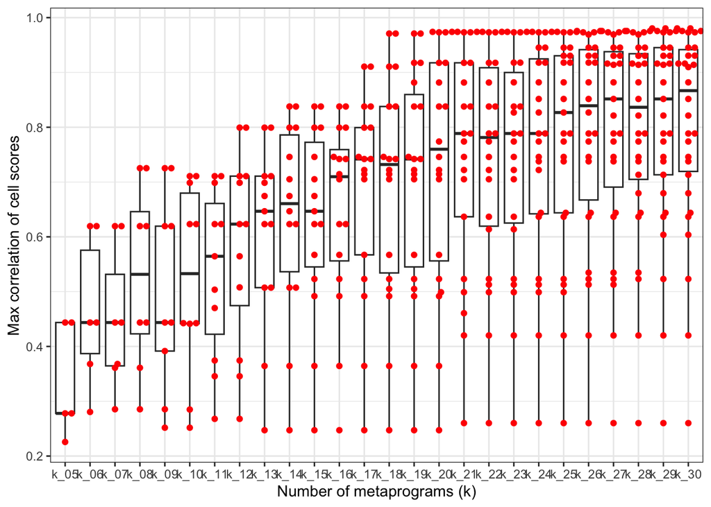

```r
ggplot(score_correlation_df, aes(x = n_metaprograms, y = max_correlation_cells)) +
  geom_boxplot(outlier.shape = NA) +
  ggbeeswarm::geom_beeswarm(color = "red") +
  labs(
    x = "Number of metaprograms (k)",
    y = "Max correlation of cell scores"
  )
```

Again, we’ll look at the distribution of all points together.

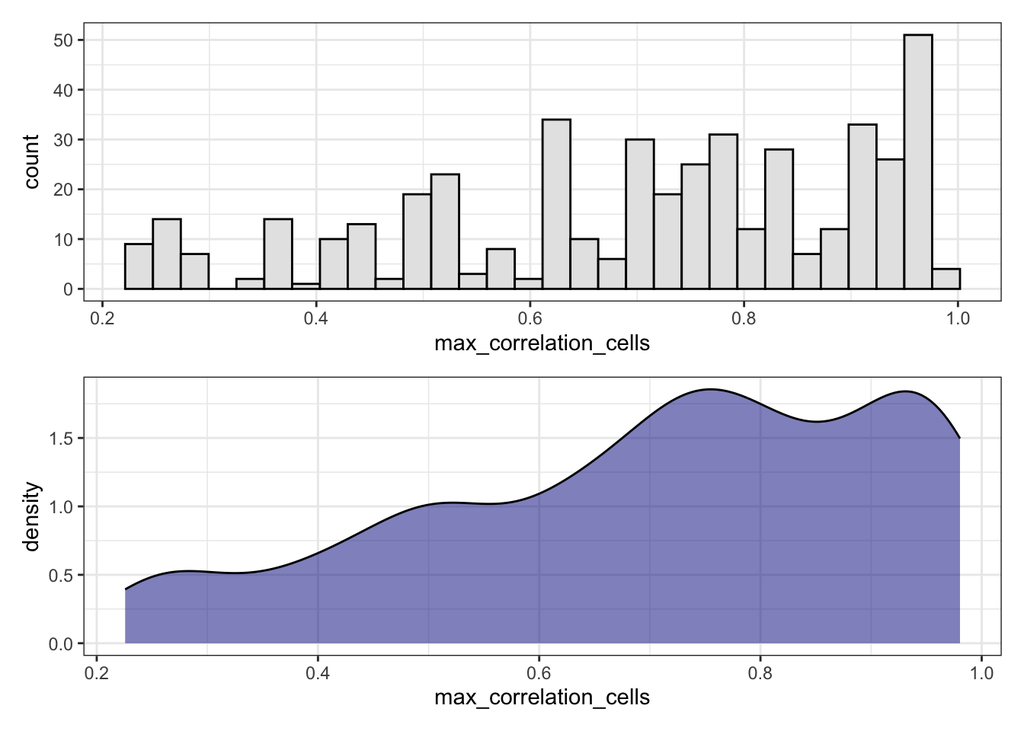

```r
plot_distribution(score_correlation_df, max_correlation_cells)
```

Notably, this correlation range is much wider and we see correlations all the way up to close to 1. We might be able to say that anything above 0.8 is considered “high” correlation given the spike in correlations > 0.8 seen when you go to k > 17.

Alternatively, we could try and define outliers as those with a zscore > 2.

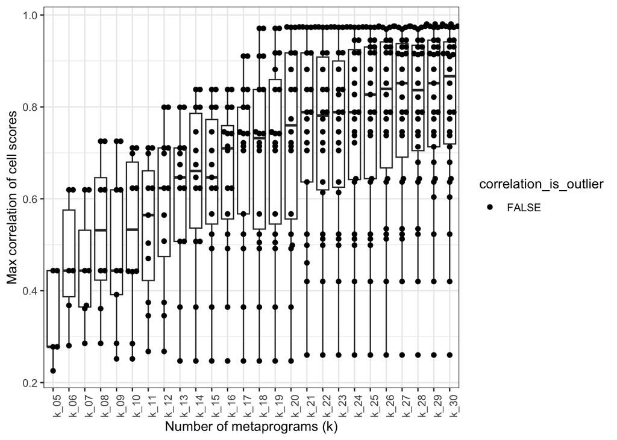

```r
score_correlation_df <- score_correlation_df |>
  dplyr::mutate(correlation_zscore = scale(max_correlation_cells),
                correlation_is_outlier = correlation_zscore > 2)

ggplot(score_correlation_df, aes(x = n_metaprograms, y = max_correlation_cells)) +
  geom_boxplot(outlier.shape = NA) +
  ggbeeswarm::geom_beeswarm(aes(color = correlation_is_outlier)) +
  scale_color_manual(values = c("black", "red")) +
  labs(
    x = "Number of metaprograms (k)",
    y = "Max correlation of cell scores"
  ) +
  theme(
    axis.text.x = element_text(angle = 90)
  )
```

Hmm it doesn’t look like there are any outliers.

```r
summary(score_correlation_df$correlation_zscore)
```

```
       V1
 Min.   :-2.2858
 1st Qu.:-0.8423
 Median : 0.1724
 Mean   : 0.0000
 3rd Qu.: 0.9047
 Max.   : 1.3071
```

Out of curiosity let’s see what would happen if you rank based on the mean correlation and look for the value of k with the minimum correlation values.

```r
score_correlation_df |>
  dplyr::group_by(n_metaprograms) |>
  dplyr::summarize(
    mean_correlation_cells = mean(max_correlation_cells)
  ) |>
  dplyr::arrange(mean_correlation_cells)
```

| n_metaprograms | mean_correlation_cells |
| --- | --- |
| k_05 | 0.3337546 |
| k_07 | 0.4486841 |
| k_06 | 0.4624699 |
| k_09 | 0.5006263 |
| k_10 | 0.5229630 |
| k_08 | 0.5279206 |
| k_11 | 0.5357022 |
| k_12 | 0.5854531 |
| k_13 | 0.6086536 |
| k_15 | 0.6324206 |

[output cut: 16 more lines]

Looks like k=5 and k=7 are at the top again.

## Metaprogram Coherence - Difference in medians

Finally, we’ll look at the difference in medians between the distribution of correlation of spectra within a given metaprogram and between metaprograms, which we will refer to as metaprogram coherence. Here we want to maximize the value.

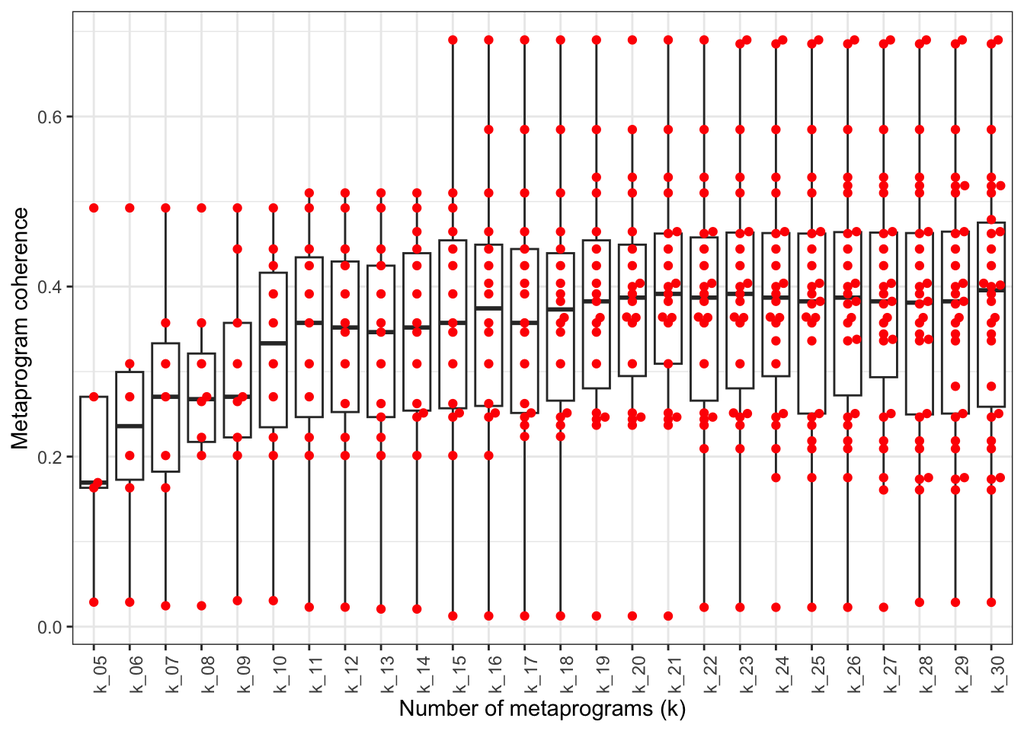

```r
ggplot(mp_metrics_df, aes(x = n_metaprograms, y = median_difference)) +
  geom_boxplot(outlier.shape = NA) +
  ggbeeswarm::geom_beeswarm(color = "red") +
  labs(
    x = "Number of metaprograms (k)",
    y = "Metaprogram coherence"
  ) +
  theme(
    axis.text.x = element_text(angle = 90)
  ) +
  theme(
    axis.text.x = element_text(angle = 90)
  )
```

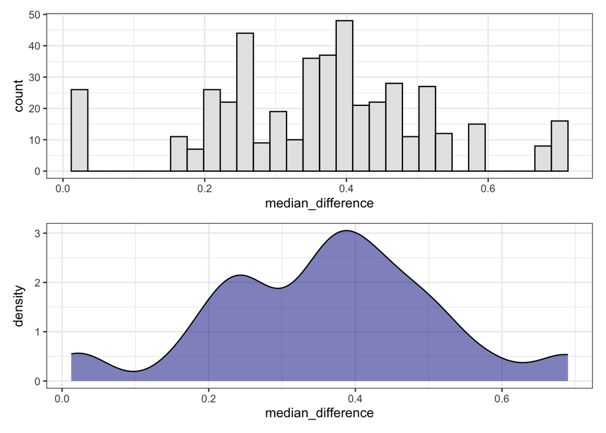

```r
plot_distribution(mp_metrics_df, median_difference)
```

Let’s formally look for some outliers by using a zscore again. We’ll call anything with z < -2 an outlier.

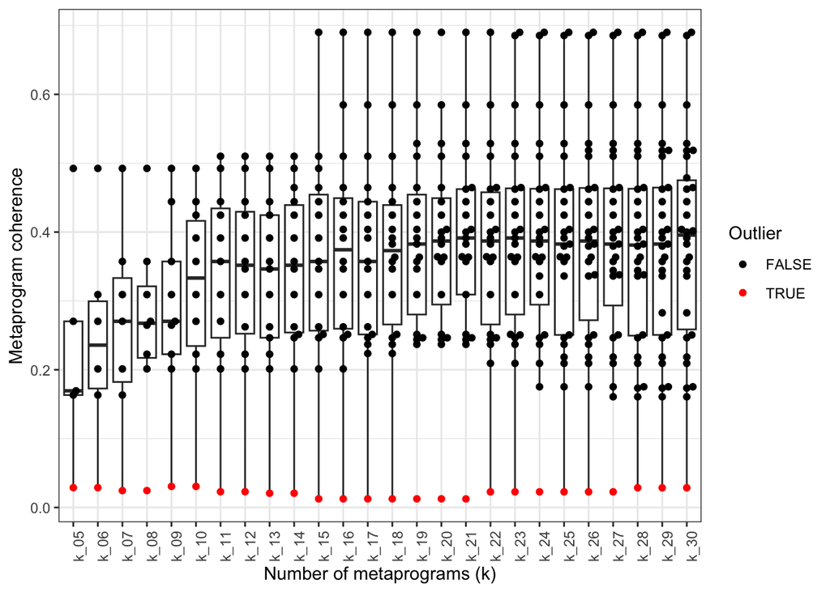

```r
mp_metrics_df <- mp_metrics_df |>
  dplyr::mutate(coherence_zscore = scale(median_difference),
                coherence_is_outlier = coherence_zscore < -2)

ggplot(mp_metrics_df, aes(x = n_metaprograms, y = median_difference)) +
  geom_boxplot(outlier.shape = NA) +
  ggbeeswarm::geom_beeswarm(aes(color = coherence_is_outlier)) +
  scale_color_manual(values = c("black", "red")) +
  labs(
    x = "Number of metaprograms (k)",
    y = "Metaprogram coherence",
    color = "Outlier"
  ) +
  theme(
    axis.text.x = element_text(angle = 90)
  )
```

As predicted, that bottom point in every value of k is considered an outlier.

It also looks like as you increase k eventually you get to a value where increasing k doesn’t provide any more increase in the difference of medians. To show this, we make an elbow plot showing the median difference for each value of k and find the value of k where the maximum occurs. Since we know we have one obvious outlier for all values of k we’ll use median as that number is not sensitive to outliers.

```r
coherence_elbow_df <- mp_metrics_df |>
  dplyr::group_by(n_metaprograms) |>
  dplyr::summarize(
    median_coherence = median(median_difference)
  ) |>
  dplyr::arrange(desc(median_coherence))
```

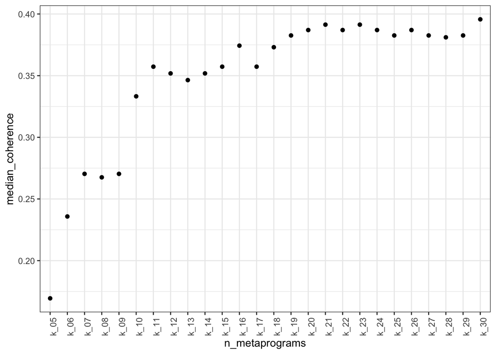

```r
ggplot(coherence_elbow_df, aes(x = n_metaprograms, median_coherence)) +
  geom_point() +
  theme(
    axis.text.x = element_text(angle = 90)
  )
```

It looks like once you get to k=11, the value hits a plateau.

Let’s try to use a quantitative approach to find the elbow.

I’m going to try out a version of the “kneedle” algorithm, see https://raghavan.usc.edu/papers/kneedle-simplex11.pdf. This involves rotating the curve so that the knee or elbow correspond to the local maxima. After rotating, the elbow is the point with the maximum difference from the line that connects the two end points of the rotated curve. The only step I’m not including is the thresholding step which finds a set of local maxima. Instead, I’ll just find a single maximum value to indicate the elbow.

```r
# function to calculate the "kneedle"
kneedle <- function(k_values, metric_values, concave = TRUE) {

  # Step 1: Smooth data to preserve original shape
  fit <- smooth.spline(k_values, metric_values)
  metric_values <- predict(fit, k_values)$y

  # Step 2: Normalize to [0, 1]
  x <- (k_values - min(k_values)) / (max(k_values) - min(k_values))
  y <- (metric_values - min(metric_values)) / (max(metric_values) - min(metric_values))

  # Step 3: Subtract the diagonal (line from first to last point)
  # This "rotates" the curve so the elbow becomes a maximum
  y_diff <- y - x  # for concave (increasing); use x - y for convex (decreasing)
  if (!concave) y_diff <- x - y

  # Step 4: The knee is the point with the maximum difference
  knee_index <- which.max(y_diff)

  k_values[knee_index]
}
```

```r
k_values <- stringr::str_remove(coherence_elbow_df$n_metaprograms, "k_") |>
  as.numeric()

kneedle(k_values, coherence_elbow_df$median_coherence, concave = TRUE)
```

```
[1] 11
```

This lines up with what I would expect. How does this change if you first remove the outlier and then find the elbow?

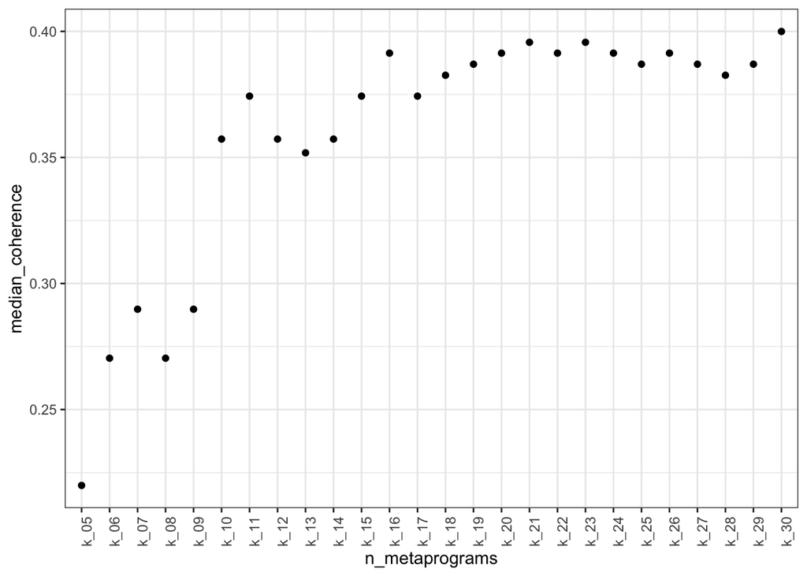

```r
filtered_coherence_elbow_df <- mp_metrics_df |>
  dplyr::filter(!coherence_is_outlier) |>
  dplyr::group_by(n_metaprograms) |>
  dplyr::summarize(
    median_coherence = median(median_difference)
  ) |>
  dplyr::arrange(desc(median_coherence))

ggplot(filtered_coherence_elbow_df, aes(x = n_metaprograms, median_coherence)) +
  geom_point() +
  theme(
    axis.text.x = element_text(angle = 90)
  )
```

```r
kneedle(k_values, filtered_coherence_elbow_df$median_coherence, concave = TRUE)
```

```
[1] 11
```

Again, we see that this is 11.

## Concluding thoughts

Some thoughts about putting everything together based on the above observations:

- We could use the cutoff defined here for the gene weight correlation metric to identify “good” and “bad” metaprograms. We can then calculate the proportion of good metaprograms to get a single number. This does mean that for the full cohort, when k < 15, all of the programs are considered good so the number will be equivalent, but I think that’s actually a good thing.
- I don’t know that we want to set cutoffs using cell score correlations just yet. It’s a pretty big range of values and having a high biological correlation between two gene sets is not out of the ordinary.
- For the coherence metric, one option is to just remove the noisey metaprogram all together and not use that metric when combining metrics outside of that.
- The other option is to calculate the median and rank the values of k based on that. My concern with that is high values of k have higher median values, but only marginally, so I wouldn’t want that to heavily influence the final results.
- We might also consider using the elbow to define a point where we see no added benefit to adding more metaprograms, but I’m not sure how exactly that would fit into defining our overall metric.